## Jorge Bueno Perez - 419034

# Computer vision - Application of Convolutional Neural Network to image classification, glasses vs no glasses

```python
import matplotlib.pyplot as plt
import matplotlib.image as mpimg
import os
import shutil
import random
```

### The `original dataset` used for this project was found on `kaggle`: `Glasses or No Glasses - https://www.kaggle.com/jeffheaton/glasses-or-no-glasses`

### However, after the process of data-cleaning I found out that the classes were `imbalanced` (more photos were `glasses` than `not_glasses`)

### I decided to use one additional dataset from Kaggle: `1 Million Fake Faces - 1 - https://www.kaggle.com/tunguz/1-million-fake-faces`, from which I took `311 adittional photos` belonging to the class `no_glasses`

### It is important to mention that in both datasets the `images were created artificially`

# 1)`Data reading` and `preparation`

### This part will be just shown in one photo located in the folder `test`, in order to show how the process looks like. However, in the project it was done in the main folder were all the images were located

```python
dir_ = "/Users/Lajobu/Desktop/test"
```

### The data does `not have labels`, this means we don't know which images are part of the group `glasses` or `no_glasses`. For this reason the first step in the process will be to `create labels`

### Firstly, the `file names` and `extensions` are going to be `extracted`. After that, it will be appended to the directory addres `dir_`

```python
import os
file = []
for root, dirs, files in os.walk(dir_):
    for filename in files:
        file.append(dir_+"/"+filename)
```

### The photos from the second dataset `1 Million Fake Faces - 1` had different format than the original dataset, hence I decided to change the format, from `png` to `jpg`

### This was done with the package `PIL`

```python
from PIL import Image
for i in range(len(file)):
    try:
        Image.open(file[i]).save(file[i][:-3] + 'jpg')
    except:
        pass
```

### At this stage we are able to create the labels of the photos. I decided to create three different categories:

- `glasses`
- `no_glasses`
- `not_clear`: As mentioned before the images were created `artificially`, hence some photos it was not clear wheter the photos belong to the class `glasses` or `no_glasses`

### The `not_clear` class will not be used in the model

# 2) `Creating labels`:

```python
from pigeonXT import annotate
from IPython.display import display, Image
```

### It is important to import the above packages at this stage, because it could create a `conflict with the package PIL`

## 2.1) `Creating annotations`

### With the help of the package `pigeonXT` we are going to create a list of annotations `ann`. The created tool is based on `pigeon-jupyter 0.1.0 documentation - https://pypi.org/project/pigeon-jupyter/`

### In each call the tool runs a `batch of 200 images`, and we should just `select the button` according to the class

```python
ann = annotate(
  file[0:200],
  options=['glasses', 'no_glasses', 'not_clear'],
  display_fn=lambda filename: display(Image(filename, width=350, height=100))
)
```

## 2.2) `Moving the images`

### After the list `ann` is created with the anotation of the 200 batches, we are ready to move the images from the general `dir_`folder to the one created for each class `glasses`, `no_glasses` and `not_clear`

```python
for k, v in ann.items():
    if v == "glasses":
        shutil.move(k, "/Users/Lajobu/Desktop/Projects/DL/Classificastion/Images/glasses")
    elif v == "no_glasses":
        shutil.move(k, "/Users/Lajobu/Desktop/Projects/DL/Classificastion/Images/no_glasses")
    else:
         shutil.move(k, "/Users/Lajobu/Desktop/Projects/DL/Classificastion/Images/not_clear")
```

### This process should be done several times, as there are more than 5000 images

# 3) `Classes overview`:

```python
from PIL import Image
```

### Once we created the different three folders with the respective images, we can see what is there

```python
dir_ = "/Users/Lajobu/Desktop/Projects/DL/Classificastion/Images"
dir_glasses = "/Users/Lajobu/Desktop/Projects/DL/Classificastion/Images/glasses"
dir_no_glasses = "/Users/Lajobu/Desktop/Projects/DL/Classificastion/Images/no_glasses"
dir_not_clear = "/Users/Lajobu/Desktop/Projects/DL/Classificastion/not_clear"

import os
glasses = []
for root, dirs, files in os.walk(dir_glasses):
    for filename in files:
        glasses.append(dir_+"/glasses/"+filename)
no_glasses = []
for root, dirs, files in os.walk(dir_no_glasses):
    for filename in files:
        no_glasses.append(dir_+"/no_glasses/"+filename)
not_clear = []
for root, dirs, files in os.walk(dir_not_clear):
    for filename in files:
        not_clear.append("/Users/Lajobu/Desktop/Projects/DL/Classificastion/not_clear/"+filename)
```

## - `glasses`

### There are `2814 images` related to the class `glasses`

```python
len(glasses)
```

```
2814
```

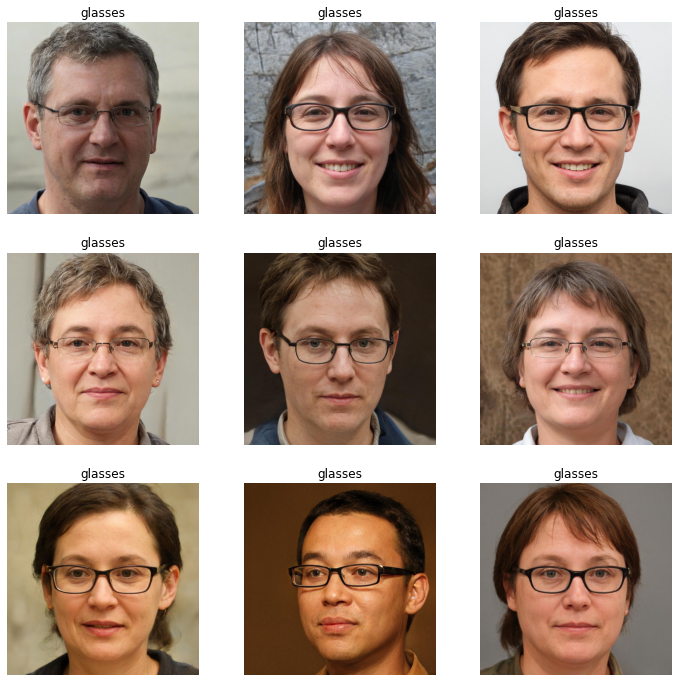

```python
plt.figure(figsize=(12, 12))
ran_num = []
for i in range(0,9):
    n = random.randint(0,len(glasses))
    ran_num.append(n)
for i in range(9):
    ax= plt.subplot(3, 3, i + 1)
    plt.imshow(mpimg.imread(glasses[ran_num[i]]))
    plt.title("glasses")
    plt.axis("off")
plt.savefig('/Users/Lajobu/Desktop/Projects/DL/Classificastion/Figures/glasses_clean.png')
```

## - `no_glasses`

### There are `2814 images` related to the class `no_glasses`

```python
len(no_glasses)
```

```
2814
```

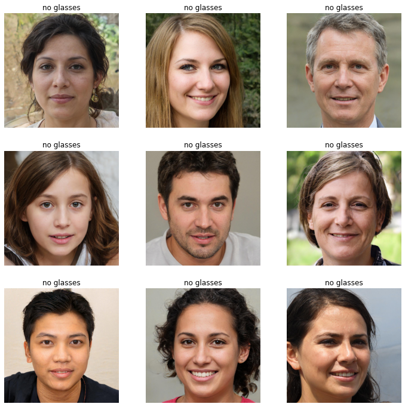

```python
plt.figure(figsize=(12, 12))
ran_num = []
for i in range(0,9):
    n = random.randint(0,len(no_glasses))
    ran_num.append(n)
for i in range(9):
    ax= plt.subplot(3, 3, i + 1)
    plt.imshow(mpimg.imread(no_glasses[ran_num[i]]))
    plt.title("no glasses")
    plt.axis("off")
plt.savefig('/Users/Lajobu/Desktop/Projects/DL/Classificastion/Figures/no_glasses_clean.png')
```

## - `not_clear`

### There are `77 images` related to the class `not_clear`, which are not going to be used in the model

```python
len(not_clear)
```

```
77
```

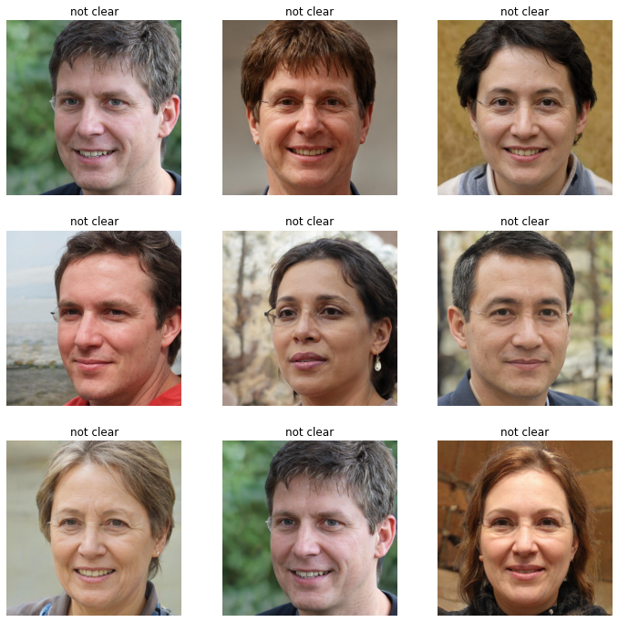

```python
plt.figure(figsize=(12, 12))
ran_num = []
for i in range(0,9):
    n = random.randint(0,len(not_clear))
    ran_num.append(n)
for i in range(9):
    ax= plt.subplot(3, 3, i + 1)
    plt.imshow(mpimg.imread(not_clear[ran_num[i]]))
    plt.title("not clear")
    plt.axis("off")
plt.savefig('/Users/Lajobu/Desktop/Projects/DL/Classificastion/Figures/not_clear.png')
```